# Текстовой редактор vi

Леснухин Даниил НПИбд-02-22

Российский Университет Дружбы Народов

29 марта, 2023, Москва, Россия

# Цель работы

Познакомиться с операционной системой Linux.Получить практические навыки работы с редактором vi,установленным по умолчанию практически во всех дистрибутивах

## Выполнение лабораторной работы

# Задание 1. Создание нового файла с использованием vi

Создаю каталог с именем ~/work/os/lab06 Перехожу во вновь созданный каталог. Вызвал vi и создаю файл hello.sh

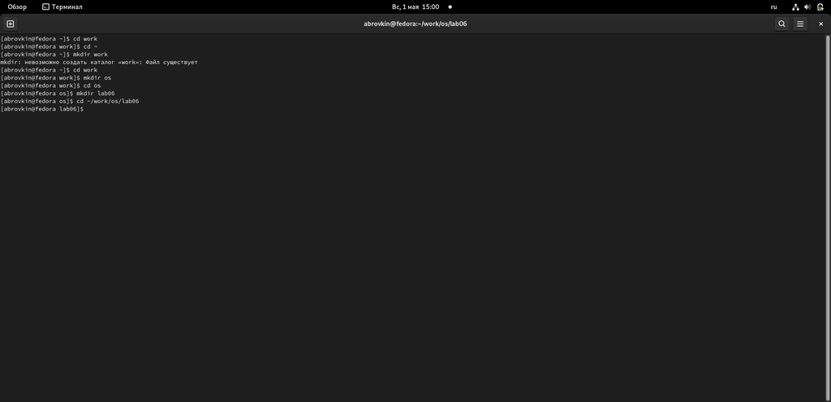

рис.1

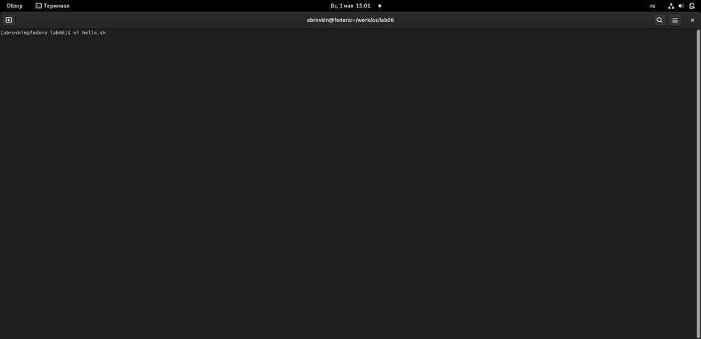

рис.2

Нажимаю клавишу i и ввожу следующий текст:

1 #!/bin/bash

2 HELL=Hello

3 function hello {

4 LOCAL HELLO=World

5 echo $HELLO

6 }

7 echo $HELLO

8 hello

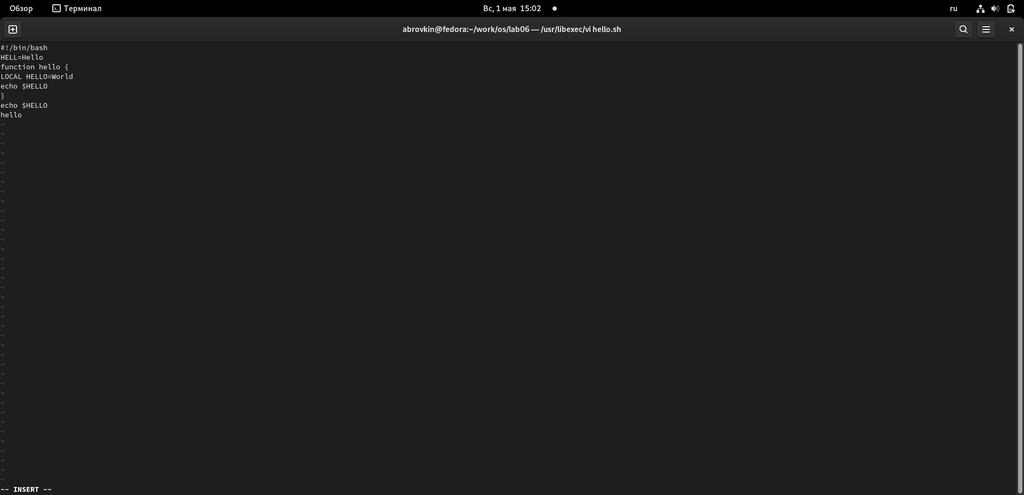

рис.3

Далее нажимаю клавишу Esc для перехода в командный режим после завершения ввода текста. Также нажимаю “:” для перехода в режим последней строки и внизу экрана появилось приглашение в виде двоеточия.

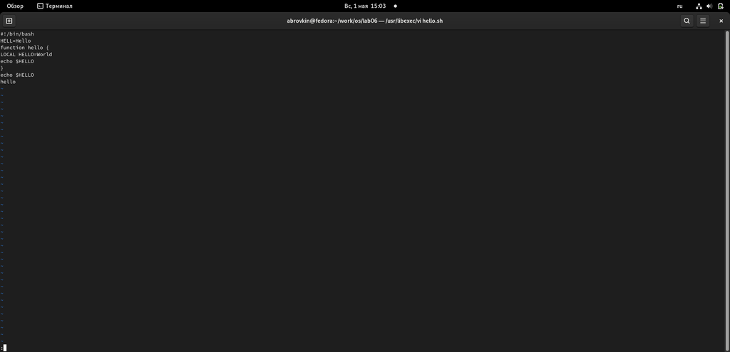

рис.4

Нажимаю w(записать) и q(выйти), а затем нажал клавишу Enter для сохранения текста и завершения работы.

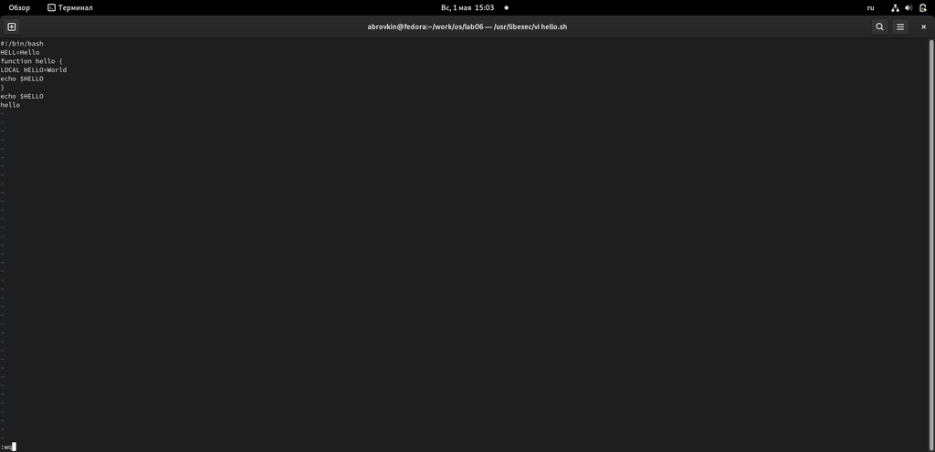

рис.5

Сделал файл исполняемым.

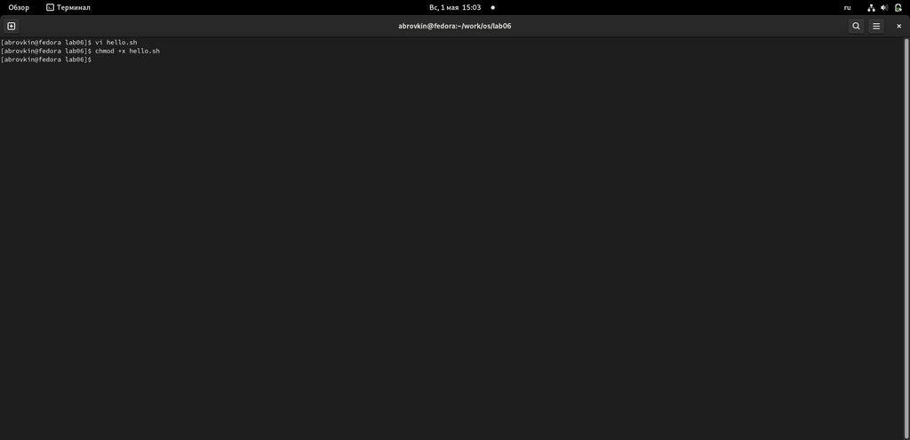

рис.6

# Задание 2. Редактирование существующего файла

Вызываю vi на редактирование файла.

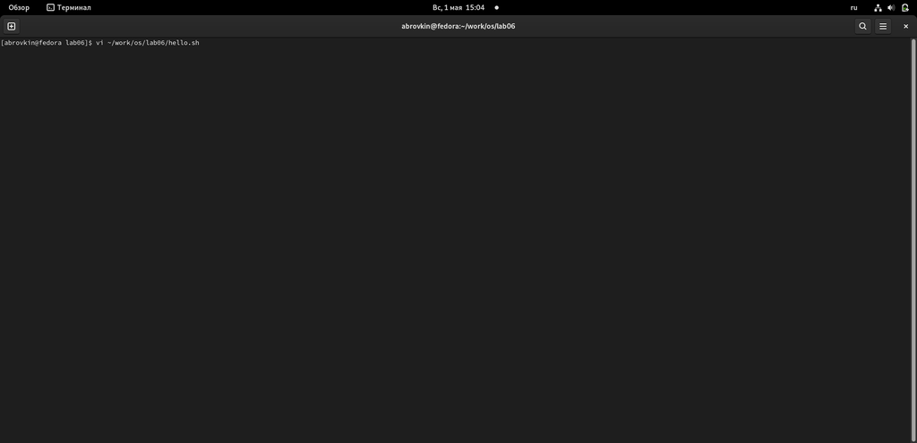

рис.6

Установил курсор в конец слова HELL второй строки.

[figure not shown]

Далее перехожу в режим вставки и заменил его на HELLO, нажал Esc для возврата в командый режим.

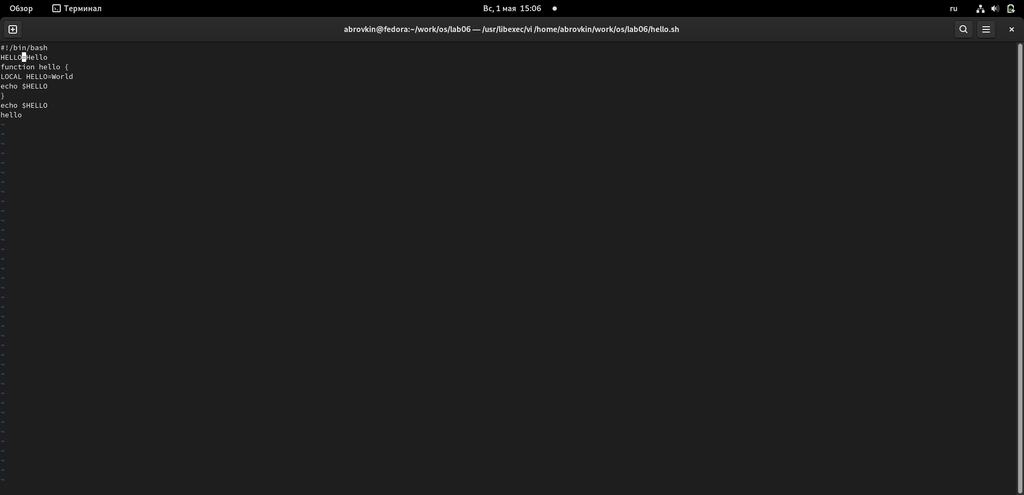

рис.8

Установлю курсор на четвертую строку и сотру слова LOCAL.

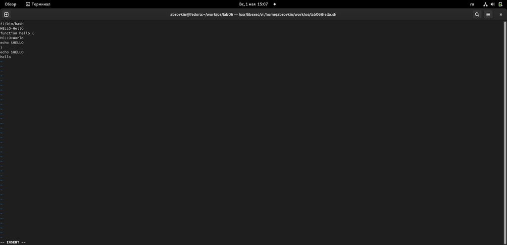

рис.9

Перешел в режим вставки и набрал следующий текст: local, нажал Esc для возврата в командный режим.

[figure not shown]

Установил курсор на последней строке файла. Вставил после неё строку, содержащую следующий текст: echo $HELLO.

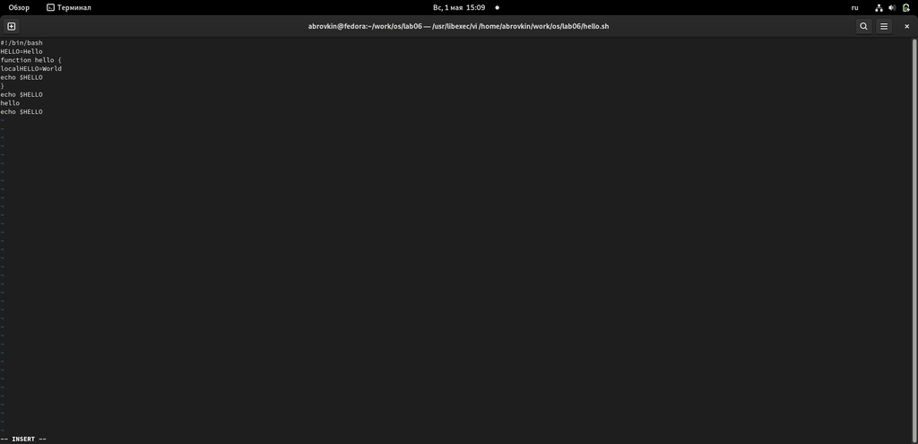

рис.11

## Вывод

Я познакомился с операционной системой Linux, получил практические навыки работы с редактором vi, установленным по умолчанию практически во всех дистрибутивах.